# TP2 - NYC Trip Duration Prediction

Group 9 - Thomas Trankle, Jaida Clarke, Andrew Tremblay and Jill van den Dungen

04/21/2021

## Introduction & Background

**Introduction:** New York City is known for their abundance of traffic, high amount of pedestrians, bicycles, and other things that could potentially clog up the road. Because of this, most people in New York avoid driving on their own and end up using taxis. Even with not having to drive on their own, the overwhelming street congestion leaves many New York visitors and residents wondering how they can make it to their destination on time. To help with this problem, our goal was to build a model that can predict how long taxi trip duration will be based on the route.

**Dataset:** The observations in this dataset, recorded in 2016, was collected by the NYC Taxi and Limousine Commission. Within the dataset contains certain features that can play a role in duration, such as day of the week, time of day, number of passengers, the distance between the pickup and dropoff location, and more. In addition to predicting trip duration, we will identify features that tend to heavily influence trip durations than others.

[figure not shown]

We load the data to our environment using read.csv function from **base R**.

```r
# Create dataframe for training and testing

# The training set consists of 1458644 observations and 11 features
train_df <- read.csv("train.csv", stringsAsFactors=F, header=T, sep=',')

# The test data consists of 625134 observations and 9 variables
# It is missing trip_duration and dropoff_time
test_df <- read.csv("test.csv", stringsAsFactors=F, header=T, sep=',')

print(names(train_df))
```

```
##  [1] "id"                 "vendor_id"          "pickup_datetime"
##  [4] "dropoff_datetime"   "passenger_count"    "pickup_longitude"
##  [7] "pickup_latitude"    "dropoff_longitude"  "dropoff_latitude"
## [10] "store_and_fwd_flag" "trip_duration"
```

## Data Cleaning

### Initial Train & Test data Statistics

To gain a better understanding of the data we are dealing with, we start by looking at the data type of each feature.

```r
# Use str() to output a list of each feature, its data type, and some instances
str(train_df)
```

```
## 'data.frame':    1458644 obs. of  11 variables:
##  $ id                : chr  "id2875421" "id2377394" "id3858529" "id3504673" ...
##  $ vendor_id         : int  2 1 2 2 2 2 1 2 1 2 ...
##  $ pickup_datetime   : chr  "2016-03-14 17:24:55" "2016-06-12 00:43:35" "2016-01-19 11:35:24" "2016-04-06 19:32:31" ...
##  $ dropoff_datetime  : chr  "2016-03-14 17:32:30" "2016-06-12 00:54:38" "2016-01-19 12:10:48" "2016-04-06 19:39:40" ...
##  $ passenger_count   : int  1 1 1 1 1 6 4 1 1 1 ...
##  $ pickup_longitude  : num  -74 -74 -74 -74 -74 ...
##  $ pickup_latitude   : num  40.8 40.7 40.8 40.7 40.8 ...
##  $ dropoff_longitude : num  -74 -74 -74 -74 -74 ...
##  $ dropoff_latitude  : num  40.8 40.7 40.7 40.7 40.8 ...
##  $ store_and_fwd_flag: chr  "N" "N" "N" "N" ...
##  $ trip_duration     : int  455 663 2124 429 435 443 341 1551 255 1225 ...
```

As you can see, our data consists mainly of numeric and categorical variables. However, if we pay special attention to some of the categorical variables, we notice that they should actually be date-time objects. We will address this point later, but for now it might be useful to get summary statistics of the given data.

```r
# Use the summary function to view summary statistics
summary(train_df$trip_duration)
```

```
##    Min. 1st Qu.  Median    Mean 3rd Qu.    Max.
##       1     397     662     959    1075 3526282
```

### Clean trip duration

To ensure we exclude these most of these outliers, given the large range, we decided to omit data that does not lie within two standard deviations of the mean for trip_duration. This is a common statistical decision which is why we chose 2 standard deviations.

```r
# First we calculate the mean and standard deviation of trip_duration
avgTrip <- mean(train_df$trip_duration)
sdTrip <- sd(train_df$trip_duration)

# import dplyer to start applying data set manipulation
library(dplyr)

# omit all observations that lie outside of 2 standard deviations of
# trip_duration
train_df %>% filter(trip_duration >= (avgTrip - 2*sdTrip)) %>%
             filter(trip_duration <= (avgTrip + 2*sdTrip)) -> train_df

# Re-look at summary statistics
summary(train_df)
```

```
##       id              vendor_id     pickup_datetime    dropoff_datetime
##  Length:1456540     Min.   :1.000   Length:1456540     Length:1456540
##  Class :character   1st Qu.:1.000   Class :character   Class :character
##  Mode  :character   Median :2.000   Mode  :character   Mode  :character
##                     Mean   :1.534
##                     3rd Qu.:2.000
##                     Max.   :2.000
##  passenger_count pickup_longitude  pickup_latitude dropoff_longitude
##  Min.   :0.000   Min.   :-121.93   Min.   :34.36   Min.   :-121.93
##  1st Qu.:1.000   1st Qu.: -73.99   1st Qu.:40.74   1st Qu.: -73.99
##  Median :1.000   Median : -73.98   Median :40.75   Median : -73.98
##  Mean   :1.664   Mean   : -73.97   Mean   :40.75   Mean   : -73.97
##  3rd Qu.:2.000   3rd Qu.: -73.97   3rd Qu.:40.77   3rd Qu.: -73.96
##  Max.   :9.000   Max.   : -61.34   Max.   :51.88   Max.   : -61.34
##  dropoff_latitude store_and_fwd_flag trip_duration
##  Min.   :32.18    Length:1456540     Min.   :    1.0
##  1st Qu.:40.74    Class :character   1st Qu.:  397.0
##  Median :40.75    Mode  :character   Median :  662.0
##  Mean   :40.75                       Mean   :  836.9
##  3rd Qu.:40.77                       3rd Qu.: 1073.0
##  Max.   :43.92                       Max.   :11411.0
```

### Latitude and Longitude

Through googling, and looking at other *Kaggle* submissions, most people define New York City to lie within the following coordinates:

- Latitude: 40.63, 40.85
- Longitude: -74.03, -73.75

Comparing this again to our summary statistics above, we still have observations outside of this geographic area. Since this project is focused on NYC, we will restrict our training data to lie within its perimeter.

```r
## Clean up coordinates -- only include obs in city limits
train_df %>% filter(pickup_longitude <= -73.75) %>%
             filter(pickup_longitude >= -74.03) %>%
             filter(pickup_latitude <= 40.85) %>%
             filter(pickup_latitude >= 40.63) %>%
             filter(dropoff_longitude <= -73.75) %>%
             filter(dropoff_longitude >= -74.03) %>%
             filter(dropoff_latitude <= 40.85) %>%
             filter(dropoff_latitude >= 40.63) -> train_df
```

### Change string dates into data-time format

As mentioned earlier, the last cleaning step is to convert pickup and dropoff dates and time into the correct data type. This is easily accomplished using a combination of *lubridate* and *dplyr*.

```r
# import lubridate package
library(lubridate)

# Change format of training date variables into date and time
train_df %>% mutate(pickup_datetime,
                    pickup_datetime = ymd_hms(pickup_datetime)) %>%
             mutate(dropoff_datetime,
                    dropoff_datetime= ymd_hms(dropoff_datetime)) -> train_df

# We can the truncate the extract only the data from the above columns
train_df %>% mutate(pickup_date = date(pickup_datetime)) %>%
  mutate(dropoff_date= date(dropoff_datetime)) -> train_df

# Repeat the above procedure for the test set
test_df %>% mutate(pickup_datetime,
                   pickup_datetime = ymd_hms(pickup_datetime)) -> test_df
test_df %>% mutate(pickup_date = date(pickup_datetime)) -> test_df
```

## Data Visualization, Preprocessing and Feature Expansion

### Skewness of Y variables

In this next section, we are going to use some visualizations tools to gain a better understanding of the data. First we want to look at the remaining spread of the Y variable (trip_duration).

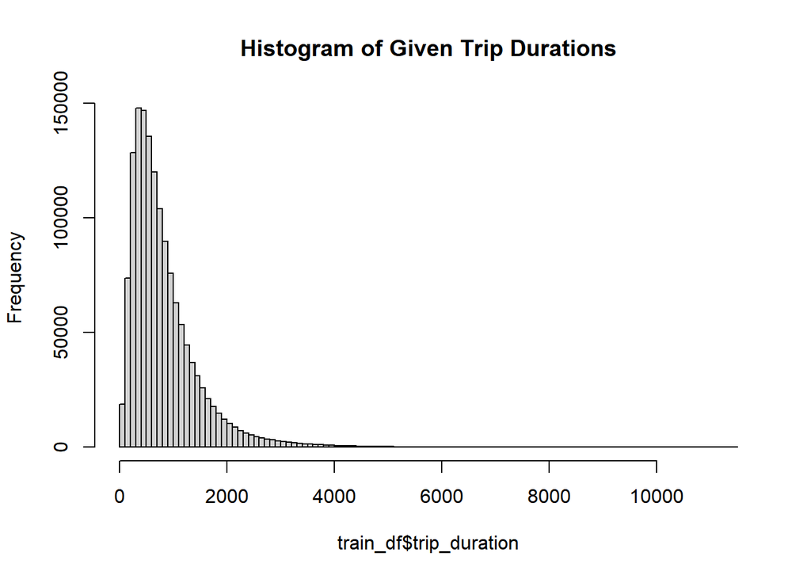

```r
# Plot histogram of trip duration with 100 bins
hist(train_df$trip_duration,
     breaks = 100, main = "Histogram of Given Trip Durations")
```

As you can see, our data is right-skewed(positive skewness). To accommodate for this, we take the log transformation of the same variable. Additionally, this gave us some intuition as why the error measure for the problem is rmsle (root-mean-square-log-error).

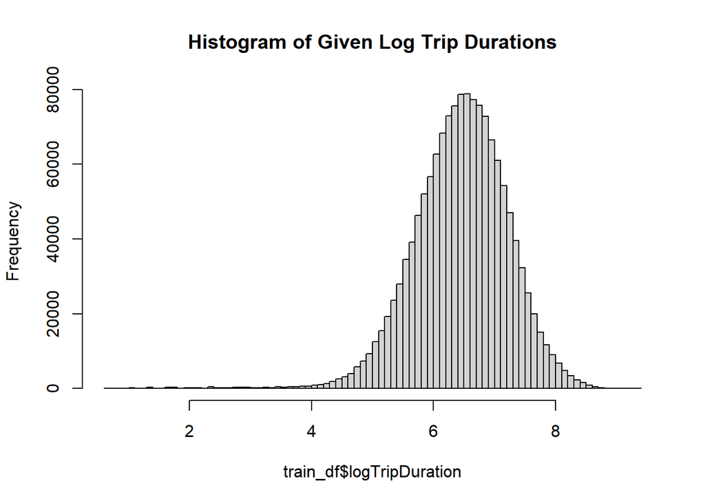

```r
# log transform Y variable
train_df %>% mutate(trip_duration,
                    logTripDuration = log(trip_duration +1)) -> train_df

# display a histogram to view changes
hist(train_df$logTripDuration,
     breaks = 100, main = "Histogram of Given Log Trip Durations")
```

The above graph now has the shape comparable to a normal distribution.

Since we are dealing with trip data, it is possibly that there is seasonality involved. To examine this hypothesis, we can look at the number of trips over time.

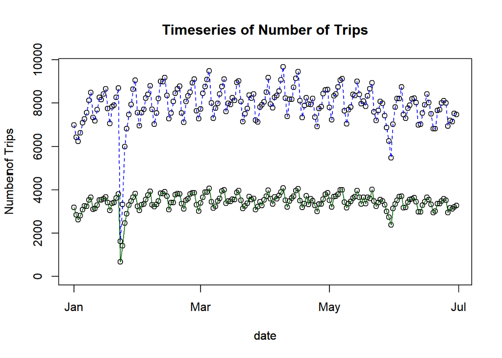

```r
## Plot Time Series of Data
# count the number of trips by date for train and test sets
train_df %>% count(date = pickup_date) -> train_date_counts
test_df %>% count(date = pickup_date) -> test_date_counts

# plot the time series graph for train
plot(train_date_counts, ylim=c(0,max(train_date_counts$n) ),
     main = 'Timeseries of Number of Trips',
     ylab = 'Number of Trips')
lines(train_date_counts,type = 'l', lty = 2, col='blue')

# fix the prior axis so train and test time-series can be on the same graph
par(new=TRUE)
plot(test_date_counts, axes = F, ylim=c(0,max(train_date_counts$n)))
lines(test_date_counts,type = 'l', lty = 1, col='darkgreen')
```

We do notice a distinct drop late January to early February. However this coincides with the test it would probably be unwise to remove it.

### Feature expansion on distances

We added 3 features to our model:

- Haversine Distance
  - Shortest distance between two points on a sphere based on coordinate locations
- Manhattan Distance
  - Sum of vertical and horizontal distances.
- Travel Direction (degrees)

We calculate all these 3 features using a combination of **dplyr** and a package called **geosphere**, which contains a haversine function that easily integrates with **dplyr’s** syntax.

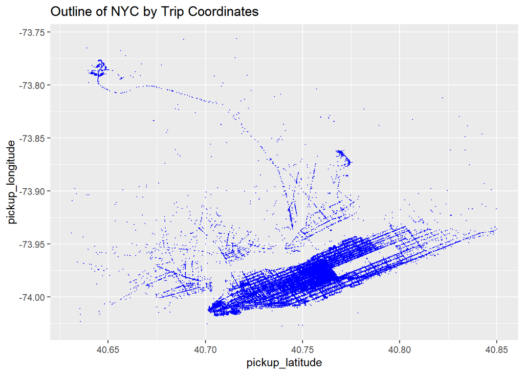

```r
# define coordinate boundaries mentioned above in variables for function
# parameters
city_long_border <- c(-74.03, -73.75)
city_lat_border <- c(40.63, 40.85)

library(ggplot2)
# visulaize coordinates using scatter plot
ggplot(train_df[1:100000,], aes(x = pickup_latitude, y = pickup_longitude)) +
  geom_point(color = 'blue', size = 0.1) +
  ggtitle("Outline of NYC by Trip Coordinates")
```

```r
# import geosphere library
library(geosphere)

# calculate haversine distance for all training observations
train_df %>% mutate(dist_haversine =
                      distHaversine(cbind(pickup_longitude,
                                          pickup_latitude),
                                    cbind(dropoff_longitude,
                                          dropoff_latitude))/1000) -> train_df

# calculate haversine distance for all test observations
test_df %>% mutate(dist_haversine =
                     distHaversine(cbind(pickup_longitude
                                         ,pickup_latitude),
                                   cbind(dropoff_longitude,
                                         dropoff_latitude))/1000) -> test_df

# calculate manahttan distance for all training observations
train_df %>% mutate(distance_dummy_manhattan = distHaversine(cbind(pickup_longitude,pickup_latitude),
cbind(dropoff_longitude,pickup_latitude))/1000 + distHaversine(cbind(pickup_longitude,pickup_latitude), cbind(pickup_longitude,dropoff_latitude))/1000) -> train_df

# calculate manhattan distance for all test observations
test_df %>% mutate(distance_dummy_manhattan =  distHaversine(cbind(pickup_longitude,pickup_latitude), cbind(dropoff_longitude,pickup_latitude))/1000 +
distHaversine(cbind(pickup_longitude,pickup_latitude), cbind(pickup_longitude,dropoff_latitude))/1000) -> test_df

# calculate trip direction for all training observations
train_df %>% mutate(direction = bearing(cbind(pickup_longitude,
                                              pickup_latitude),
                                        cbind(dropoff_longitude,
                                              dropoff_latitude))) -> train_df

# calculate trip direction for all test observations
test_df %>% mutate(direction = bearing(cbind(pickup_longitude,
                                             pickup_latitude),
                                       cbind(dropoff_longitude,
                                             dropoff_latitude))) -> test_df
```

### Locations and Neighbourhoods

We also wanted to expand the data by adding neighborhoods to the data. To do this, we used K-Means clustering on the coordinates to create 100 groups.

Importantly, we had to limit the number of samples we used to create the clusters. This is because of memory constraints on our laptops. The reason K-Means is appropriate here is because K-means is a least-squares optimization problem. K-Means tries to find the least-squares partition of the data, thus attempting to create small close knit clusters (small inter cluster distance), which we can define as neighborhoods.

We can the use the **clue** package to predict the cluster labels for the remaining observations.

```r
## create Neighborhoods

# merge pickup and dropoff coordinates into a single dataframe
coords <- rbind(cbind(train_df$pickup_latitude,train_df$pickup_longitude),
                cbind(train_df$dropoff_latitude, train_df$dropoff_longitude))

# randomly select 10,000 observations to run kmeans on
randomSamples <- sample(1:nrow(coords),10000)
randomCoords <- coords[randomSamples,]

# apply kmeans clustering to the selected coordinate locations above
km.out <- kmeans(randomCoords, centers = 100)

# import the clue library to predict cluster locations of observations not used
# in kmeans
library(clue)
cl_predict(km.out,newdata = coords)

# predict pickup neighborhoods for training set
train_df$pickup_cluster <- cl_predict(km.out,
                                     cbind(train_df$pickup_latitude,
                                           train_df$pickup_longitude))

# predict pickup neighborhoods for test set
test_df$pickup_cluster <- cl_predict(km.out,cbind(test_df$pickup_latitude,
                                                  test_df$pickup_longitude))

# predict dropoff neighborhoods for training set
train_df$dropoff_cluster <- cl_predict(km.out,cbind(train_df$dropoff_latitude, train_df$dropoff_longitude))

# predict dropoff neighborhoods for test set
test_df$dropoff_cluster <- cl_predict(km.out,cbind(test_df$dropoff_latitude, test_df$dropoff_longitude))
```

We can now re-visualize the above scatter plot with the newly defined clusters.

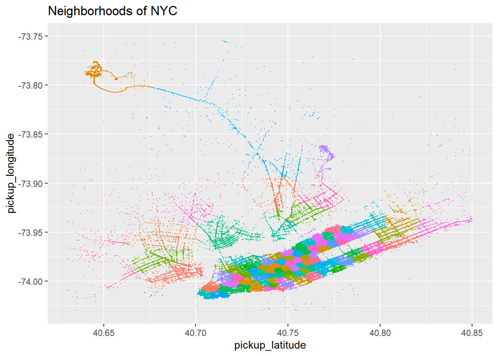

```r
# visualize coordinates using scatter plot
ggplot(train_df[1:500000,], aes(x = pickup_latitude, y = pickup_longitude)) +
  geom_point(aes(colour = factor(pickup_cluster)), size = 0.1,show.legend = F) +
  ggtitle("Neighborhoods of NYC")
```

### Type Conversion

Earlier, we created a date-time column. We now want to split that data into hour, day, day of the week and month respectively.

```r
# extract months
train_df$Month <- as.factor(month(train_df$pickup_date))
test_df$Month <- as.factor(month(test_df$pickup_date))

# extract numeric day within month
train_df$Day <- as.factor(day(train_df$pickup_date))
test_df$Day <- as.factor(day(test_df$pickup_date))

# extract hour within day
train_df$Hour <- as.factor(hour(train_df$pickup_datetime))
test_df$Hour <- as.factor(hour(test_df$pickup_datetime))

# extract day of the week
train_df$DayOfWeek <- as.factor(weekdays(train_df$pickup_date))
test_df$DayOfWeek <- as.factor(weekdays(test_df$pickup_date))
```

Additionally, a lot of our numeric data is actually better described as categorical information. For example, the neighborhoods (cluster locations) columns are analogous to zip codes. So, we will quickly convert all these into factors.

```r
# change to factors
train_df$vendor_id <- as.factor(train_df$vendor_id)
test_df$vendor_id <- as.factor(test_df$vendor_id)

train_df$passenger_count <- as.factor(train_df$passenger_count)
test_df$passenger_count <- as.factor(test_df$passenger_count)

train_df$store_and_fwd_flag <- as.factor(train_df$store_and_fwd_flag)
test_df$store_and_fwd_flag <- as.factor(test_df$store_and_fwd_flag)

train_df$pickup_cluster <- as.factor(train_df$pickup_cluster)
test_df$pickup_cluster <- as.factor(test_df$pickup_cluster)
train_df$dropoff_cluster <- as.factor(train_df$dropoff_cluster)
test_df$dropoff_cluster <- as.factor(test_df$dropoff_cluster)
```

### Append Additional Data

Lastly, since our given data did not provide enough columns itself. We also decided to locate more data. On kaggle, we found an OSRM data set for New York that matches the ID pairs in our given data set. This data set defines the fastest routes for all trips in our data set. However, even though it gives the total time and distance traveled, these are the fastest mappings and do not take into consideration things like traffic and alternative routes. Therefore, they are not a direct measure of the prediction variable.

```r
# https://www.kaggle.com/oscarleo/new-york-city-taxi-with-osrm?select=fastest_routes_test.csv

# import and concatenate new data with existing training set
fr1 <- read.csv('fastest_routes_train_part_1.csv')[,c('id', 'total_distance', 'total_travel_time',  'number_of_steps')]
fr2 <- read.csv('fastest_routes_train_part_2.csv')[,c('id', 'total_distance', 'total_travel_time', 'number_of_steps')]

# import and concatenate new data with existing test set
test_street_info = read.csv('fastest_routes_test.csv')[,
                               c('id', 'total_distance', 'total_travel_time', 'number_of_steps')]

# merge two training sets
train_street_info <- rbind(fr1,fr2)

# left join according to id column in both data sets
train_df <- left_join(train_df,train_street_info,by="id")
test_df <- left_join(test_df,test_street_info,by="id")
```

We have now reached the end of our preprocessing stage. The final step before moving on to our models is to select the columns of interest. Otherwise, we will have a lot of collinearity since we created many, more explanatory features, from existing ones.

```r
train_df %>% select(c('dist_haversine','distance_dummy_manhattan',
                      'direction','pickup_cluster','dropoff_cluster',
                      'total_distance','total_travel_time','number_of_steps',
                      'vendor_id','passenger_count','store_and_fwd_flag',
                      'Month','Day','Hour','DayOfWeek','trip_duration')) -> Train_Master

test_df %>% select(c('dist_haversine','distance_dummy_manhattan',
                      'direction','pickup_cluster','dropoff_cluster',
                      'total_distance','total_travel_time','number_of_steps',
                      'vendor_id','passenger_count','store_and_fwd_flag',
                      'Month','Day','Hour','DayOfWeek')) -> Test_Master

dim(Train_Master)
```

```
## [1] 1437128      16
```

```r
dim(Test_Master)
```

```
## [1] 625134     15
```

```r
# Last check for NA's possibly introduced via feature expansion
sum(is.na(Test_Master))
```

```
## [1] 0
```

```r
Train_Master <- na.omit(Train_Master)
```

## Train and Validation

To train our model, we will be using the **caret** library to partition our training data into train and validation sets.

```r
# import caret library
library(caret)

# create a 80-20 split of the training data
train_val_split <- createDataPartition(Train_Master$trip_duration, p = .8, list = F)
#XMatrix <- sparse.model.matrix(trip_duration ~ ., data = Train_Master)

# construct feature and prediction training sets
Train.X <- data.matrix(subset(Train_Master[train_val_split,],select = -trip_duration))
Train.Y <- log(Train_Master$trip_duration)[train_val_split]

# construct feature and prediction validation sets
Val.X <-  data.matrix(subset(Train_Master[-train_val_split,],select = -trip_duration))
Val.Y <- log(Train_Master$trip_duration)[-train_val_split]

# convert test set into a matrix
Test.X <- data.matrix(Test_Master)
```

## Model Critiques

### Lasso

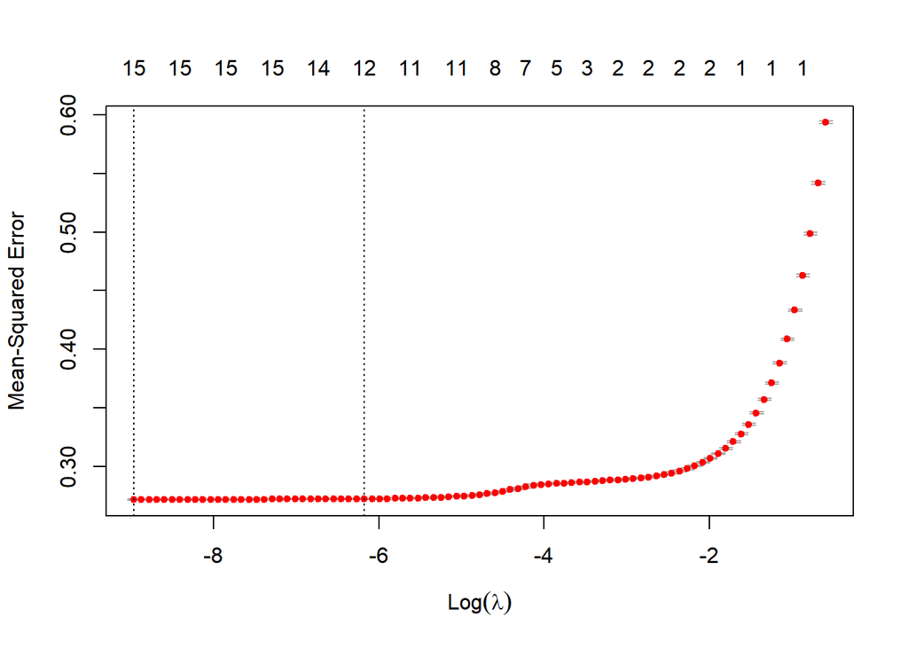

```r
library(glmnet)

# Use cross-validation
cv_lasso = cv.glmnet(Train.X, Train.Y, alpha=1) # Lasso regression
plot(cv_lasso)
```

We can extract the best lambda from cross validation.

```r
(best_lambda <- cv_lasso$lambda.min)
```

```
## [1] 0.0001276496
```

Make our own predictions on validation set.

```r
mod.lasso <- glmnet(Train.X, Train.Y, alpha = 1,lambda = best_lambda)

# Check prediction error in the testing dataset
lasso_pred <- predict(mod.lasso, s = best_lambda, newx = Val.X)
# The Mean squared error (MSE)
(error_Lasso <- sqrt(mean((lasso_pred - Val.Y)^2)))
```

```
## [1] 0.5215697
```

### Random Forest

Here is our implementation of Random Forest based on other user’s submission.

This model took 38 minutes to train. It is very slow.

```r
library(randomForest)
RFmodel <- randomForest(x = Train.X,
                    y = Train.Y,
                    importance=TRUE,
                    ntree=500,
                    mtry = sqrt(15),
                    maxnodes = 90)
```

Call: randomForest(x = Train.X, y = Train.Y, ntree = 500, mtry = sqrt(15),  
maxnodes = 90, importance = TRUE) Type of random forest: regression Number of trees: 500 No. of variables tried at each split: 4

```
      Mean of squared residuals: 0.1782996
                % Var explained: 69.99
```

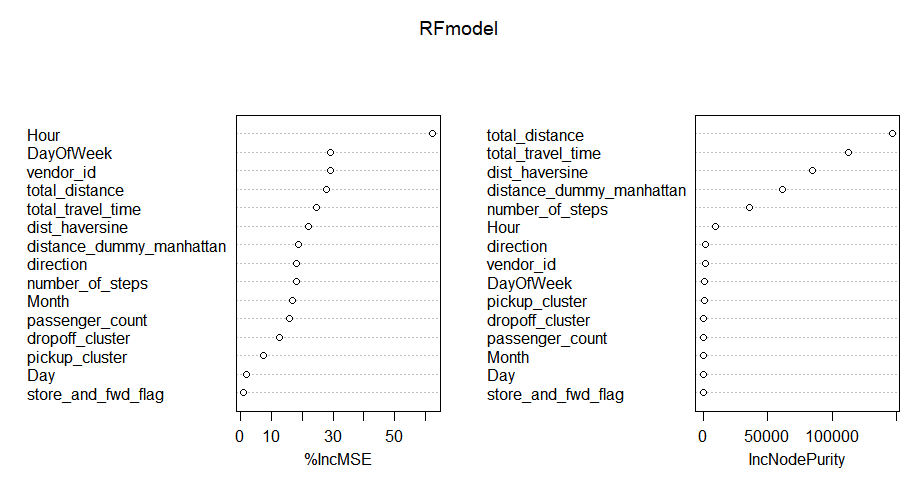

varImpPlot(RFmodel)

Evaluate on validation set.

```r
RFyhat <- predict(RFmodel, newdata = Val.X)
ErrorRF <- sqrt(mean((RFyhat - Val.Y)^2))
ErrorRF
```

[1] 0.4207632

## eXtreme Gradient Boosting

### Initial Implementation

XGBoost was the best model to use on this data set because it highly flexible and versatile and also handles large-scale problems efficiently. This is directly correlated to its ability to push the limits of computing power for boosted trees algorithms as it was built and developed for the sole purpose of model performance and computational speed.

First step, is to create of XGBoost matrices for our train and validation sets.

```r
library(xgboost)
dtrain <- xgb.DMatrix(Train.X, label = Train.Y)
dval <- xgb.DMatrix(Val.X, label = Val.Y)
```

Next, we define the parameters we want the model to use.

```r
# Train an xgboost model
watchlist <- list(train = dtrain, val = dval)
param <- list(eta = .5, # learning rate
             nthread = -1, # number of parallel threads
             object="reg:squaredlogerror", # regression (for classification, specify "binary:logistic")
             max.depth=10, # number of splits
             verbose = 1,
             subsample = 0.9,
             booster ='gbtree',
             lambda = 1,
             colsample_bytree = 0.9,
             maximize = F,
             min_child_weight = 1) # print training error)
```

Lastly, we train the model.

```r
xgboostTrip <- xgb.train(params = param,
                         data = dtrain,
                         nrounds = 1000,
                         watchlist = watchlist,
                         early_stopping_rounds = 50,
                         eval_metric = 'rmse')
```

[output not shown]

### Tuning the model

To tune the model, we will use cross validation and random parameter indexing.

```r
# Random parameters
best_param <- list()    #empty list to different parameter combinations
best_seednumber <- 1234 # set the seed
best_rmse <- Inf        # initilaize the best rmse (minimization objective)
best_rmse_index <- 0    # counter to append results per interation

set.seed(1234)

# Run 1000 random iterations
for (iter in 1:1000) {
  param <- list(objective = "reg:linear",  # For regression
                eval_metric = "rmse",      # rmse is used for regression
                max_depth = sample(6:10, 1),
                eta = runif(1, .01, .1),   # Learning rate, default: 0.3
                subsample = runif(1, .6, .9),
                colsample_bytree = runif(1, .5, .8),
                min_child_weight = sample(5:10, 1), # These two are important
                max_delta_step = sample(5:10, 1)    # Can help to focus error
                                                    # into a small range.
  )
  cv.nround <-  1000
  cv.nfold <-  5 # 5-fold cross-validation
  seed.number  <-  sample.int(10000, 1) # set seed for the cv
  set.seed(seed.number)

  # mdcv is common variable name for XGBoost cross validation
  mdcv <- xgb.cv(data = dtrain, params = param,
                 nfold = cv.nfold, nrounds = cv.nround,
                 verbose = F, early_stopping_rounds = 15, maximize = FALSE)

  min_rmse_index  <-  mdcv$best_iteration
  min_rmse <-  mdcv$evaluation_log[min_rmse_index]$test_rmse_mean

  if (min_rmse < best_rmse) {
    best_rmse <- min_rmse
    best_rmse_index <- min_rmse_index
    best_seednumber <- seed.number
    best_param <- param
  }
}
```

Our best parameters were

```r
# best_param
```

$objective [1] “reg:linear”

$eval_metric [1] “rmse”

$max_depth [1] 9

$eta [1] 0.06600695

$subsample [1] 0.7827824

$colsample_bytree [1] 0.6870138

$min_child_weight [1] 9

$max_delta_step [1] 8

### Rerun with New Paramters

```r
# Train an xgboost model
watchlist <- list(train = dtrain, val = dval)
param <- list(eta = 0.06600695, # learning rate
             nthread = -1, # number of parallel threads
             object="reg:linear",
             max.depth=9, # number of splits
             verbose = 0,
             subsample = 0.7827824,
             booster ='gbtree',
             lambda = 1,
             colsample_bytree = 0.6870138,
             maximize = F,
             min_child_weight = 9,
             max_delta_step = 8)
```

Lastly, we train the model.

```r
xgboostTrip <- xgb.train(params = param,
                         data = dtrain,
                         nrounds = 1000,
                         watchlist = watchlist,
                         early_stopping_rounds = 50,
                         eval_metric = 'rmse')
```

```r
XBGpred <- predict(xgboostTrip, dval)
(XBG_error <- sqrt(mean((XBGpred - Val.Y)^2)))
```

```
## [1] 0.3379605
```

## References

- Gareth James, Daniela Witten, Trevor Hastie, Robert Tibshirani. (2013). An introduction to statistical learning : with applications in R. New York :Springer
- https://www.kaggle.com/neomatrix369/chaieda-nyc-taxi-trip-duration-analysis
- https://www.kaggle.com/quentinmonmousseau/ml-workflow-lightgbm-0-37-randomforest-0-39
- https://bookdown.org/yihui/rmarkdown-cookbook/hide-one.html
- https://liuyanguu.github.io/post/2018/07/09/extreme-gradient-boosting-xgboost-better-than-random-forest-or-gradient-boosting/#:~:text=It%20repetitively%20leverages%20the%20patterns,random%20forest%20in%20my%20case.